# TA_class_1017

Hochia

2019/10/15

# New Project

File > New Project..

[figure not shown]

New Project

Set the directory name and the subdirectory.

# R Markdown

You can write the report with RMarkdown. It can generate HTML, PDF, Word, and PPT documents. Furthermore, math equations can be write with LaTex format.

> Find the cheet sheet from *Help > Cheetsheets > R Markdown Cheet Sheet*

Create your R Markdown!

[figure not shown]

R Markdown

Add the title and author name.

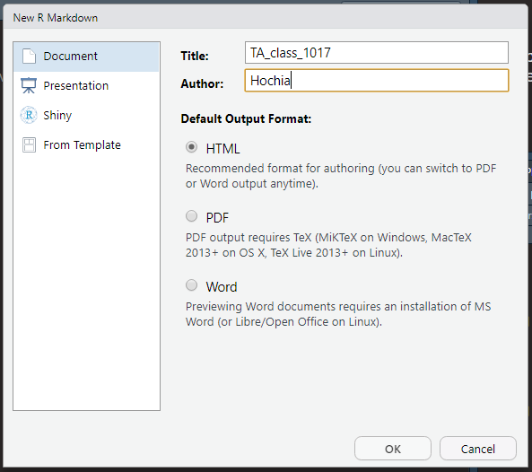

Setup

Kick the “Knit” button.

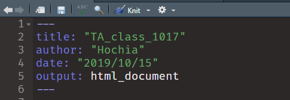

Knit

# R Code Chunks

shortcut

`Ctrl + Alt + I` on Windows

`Cmd + Option + I` on macOS

Add your R code in code chunk, then R Markdown will run it.

````
```{r}
summary(cars)
```
````

```r
x = 5  # radius of a circle
```

For a circle with the radius 5, its area is 78.5398163.

# LaTex

Use `$` to add math equations in the paragraph.

`the acceptance rate in $95\%$ confidence`

the acceptance rate in $95\%$ confidence

Use `$$` to add math equations in single or multiple lines.

```
$$
f_X(x) = {x-1 \choose r-1} p^r (1-p)^{x-r} I_{(r,r+1, \dots)} (x)
$$
```

$$f_X(x) = {x-1 \choose r-1} p^r (1-p)^{x-r} I_{(r,r+1, \dots)} (x)$$

```
$$
\begin{aligned}
f_X(x) = {x-1 \choose r-1} p^r (1-p)^{x-r} I_{(r,r+1, \dots)} (x)
f_X(x) = {x-1 \choose r-1} p^r (1-p)^{x-r} I_{(r,r+1, \dots)} (x)
\end{aligned}
$$
```

$$\begin{aligned}
f_X(x) = {x-1 \choose r-1} p^r (1-p)^{x-r} I_{(r,r+1, \dots)} (x)\\
f_X(x) = {x-1 \choose r-1} p^r (1-p)^{x-r} I_{(r,r+1, \dots)} (x)
\end{aligned}$$

For more information, see [Latex](https://latex.wikia.org/wiki/List_of_LaTeX_symbols) in Wiki.

# Wrangle with Data

## Prerequisite

```r
# install.packages("tidyverse")
library(tidyverse)
```

Tidyverse contains the packages you may need to use in data science, including ggplot2, dplyr, etc. So you do not need to install them individually.

## Data

```r
ggplot2::mpg
```

```
#> # A tibble: 234 x 11
#>    manufacturer model displ  year   cyl trans drv     cty   hwy fl    class
#>    <chr>        <chr> <dbl> <int> <int> <chr> <chr> <int> <int> <chr> <chr>
#>  1 audi         a4      1.8  1999     4 auto~ f        18    29 p     comp~
#>  2 audi         a4      1.8  1999     4 manu~ f        21    29 p     comp~
#>  3 audi         a4      2    2008     4 manu~ f        20    31 p     comp~
#>  4 audi         a4      2    2008     4 auto~ f        21    30 p     comp~
#>  5 audi         a4      2.8  1999     6 auto~ f        16    26 p     comp~
#>  6 audi         a4      2.8  1999     6 manu~ f        18    26 p     comp~
#>  7 audi         a4      3.1  2008     6 auto~ f        18    27 p     comp~
#>  8 audi         a4 q~   1.8  1999     4 manu~ 4        18    26 p     comp~
#>  9 audi         a4 q~   1.8  1999     4 auto~ 4        16    25 p     comp~
#> 10 audi         a4 q~   2    2008     4 manu~ 4        20    28 p     comp~
#> # ... with 224 more rows
```

`?ggplot2::mpg` # For more information

Or you can simply call `?mpg` if you had already call the library.

## Select columns with `select()`

```r
df <- select(mpg, manufacturer, cty, hwy, class)
df
summary(df)
table(df %>% select(manufacturer, class))
```

```r
df <- select(mpg, manufacturer, cty, hwy, class)
df
```

```
#> # A tibble: 234 x 4
#>    manufacturer   cty   hwy class
#>    <chr>        <int> <int> <chr>
#>  1 audi            18    29 compact
#>  2 audi            21    29 compact
#>  3 audi            20    31 compact
#>  4 audi            21    30 compact
#>  5 audi            16    26 compact
#>  6 audi            18    26 compact
#>  7 audi            18    27 compact
#>  8 audi            18    26 compact
#>  9 audi            16    25 compact
#> 10 audi            20    28 compact
#> # ... with 224 more rows
```

```r
summary(df)
```

```
#>  manufacturer            cty             hwy           class
#>  Length:234         Min.   : 9.00   Min.   :12.00   Length:234
#>  Class :character   1st Qu.:14.00   1st Qu.:18.00   Class :character
#>  Mode  :character   Median :17.00   Median :24.00   Mode  :character
#>                     Mean   :16.86   Mean   :23.44
#>                     3rd Qu.:19.00   3rd Qu.:27.00
#>                     Max.   :35.00   Max.   :44.00
```

```r
table(df %>% select(manufacturer, class))
```

```
#>             class
#> manufacturer 2seater compact midsize minivan pickup subcompact suv
#>   audi             0      15       3       0      0          0   0
#>   chevrolet        5       0       5       0      0          0   9
#>   dodge            0       0       0      11     19          0   7
#>   ford             0       0       0       0      7          9   9
#>   honda            0       0       0       0      0          9   0
#>   hyundai          0       0       7       0      0          7   0
#>   jeep             0       0       0       0      0          0   8
#>   land rover       0       0       0       0      0          0   4
#>   lincoln          0       0       0       0      0          0   3
#>   mercury          0       0       0       0      0          0   4
#>   nissan           0       2       7       0      0          0   4
#>   pontiac          0       0       5       0      0          0   0
#>   subaru           0       4       0       0      0          4   6
#>   toyota           0      12       7       0      7          0   8
#>   volkswagen       0      14       7       0      0          6   0
```

## Filter rows with `filter()`

Logic “and”

```r
filter(df, class == "compact", cty < 20)
```

```
#> # A tibble: 21 x 4
#>    manufacturer   cty   hwy class
#>    <chr>        <int> <int> <chr>
#>  1 audi            18    29 compact
#>  2 audi            16    26 compact
#>  3 audi            18    26 compact
#>  4 audi            18    27 compact
#>  5 audi            18    26 compact
#>  6 audi            16    25 compact
#>  7 audi            19    27 compact
#>  8 audi            15    25 compact
#>  9 audi            17    25 compact
#> 10 audi            17    25 compact
#> # ... with 11 more rows
```

Logic “or”

These three are equivalent.

```r
filter(df, class == "compact" | class == "suv")
df %>% filter(class == "compact" | class == "suv")
df %>% filter(class %in% c("compact", "suv"))
```

```r
filter(df, class == "compact" | class == "suv")
```

```
#> # A tibble: 109 x 4
#>    manufacturer   cty   hwy class
#>    <chr>        <int> <int> <chr>
#>  1 audi            18    29 compact
#>  2 audi            21    29 compact
#>  3 audi            20    31 compact
#>  4 audi            21    30 compact
#>  5 audi            16    26 compact
#>  6 audi            18    26 compact
#>  7 audi            18    27 compact
#>  8 audi            18    26 compact
#>  9 audi            16    25 compact
#> 10 audi            20    28 compact
#> # ... with 99 more rows
```

```r
df %>% filter(class == "compact" | class == "suv")
```

```
#> # A tibble: 109 x 4
#>    manufacturer   cty   hwy class
#>    <chr>        <int> <int> <chr>
#>  1 audi            18    29 compact
#>  2 audi            21    29 compact
#>  3 audi            20    31 compact
#>  4 audi            21    30 compact
#>  5 audi            16    26 compact
#>  6 audi            18    26 compact
#>  7 audi            18    27 compact
#>  8 audi            18    26 compact
#>  9 audi            16    25 compact
#> 10 audi            20    28 compact
#> # ... with 99 more rows
```

```r
df %>% filter(class %in% c("compact", "suv"))
```

```
#> # A tibble: 109 x 4
#>    manufacturer   cty   hwy class
#>    <chr>        <int> <int> <chr>
#>  1 audi            18    29 compact
#>  2 audi            21    29 compact
#>  3 audi            20    31 compact
#>  4 audi            21    30 compact
#>  5 audi            16    26 compact
#>  6 audi            18    26 compact
#>  7 audi            18    27 compact
#>  8 audi            18    26 compact
#>  9 audi            16    25 compact
#> 10 audi            20    28 compact
#> # ... with 99 more rows
```

## Summary

You can work this way!

```r
mpg %>%
  select(manufacturer, cty, hwy, class) %>%
  filter(class %in% c("compact", "suv"))
```

```
#> # A tibble: 109 x 4
#>    manufacturer   cty   hwy class
#>    <chr>        <int> <int> <chr>
#>  1 audi            18    29 compact
#>  2 audi            21    29 compact
#>  3 audi            20    31 compact
#>  4 audi            21    30 compact
#>  5 audi            16    26 compact
#>  6 audi            18    26 compact
#>  7 audi            18    27 compact
#>  8 audi            18    26 compact
#>  9 audi            16    25 compact
#> 10 audi            20    28 compact
#> # ... with 99 more rows
```

# Homework

Wrangle with `ggplot2::mpg` and show the result.

1. Select `manufacturer`, `year`, and `displ`.
2. Filter `year` is 1999 and `displ < 2`.

Reference solution

```
#> # A tibble: 234 x 3
#>    manufacturer  year displ
#>    <chr>        <int> <dbl>
#>  1 audi          1999   1.8
#>  2 audi          1999   1.8
#>  3 audi          2008   2
#>  4 audi          2008   2
#>  5 audi          1999   2.8
#>  6 audi          1999   2.8
#>  7 audi          2008   3.1
#>  8 audi          1999   1.8
#>  9 audi          1999   1.8
#> 10 audi          2008   2
#> # ... with 224 more rows
```

```
#> # A tibble: 17 x 3
#>    manufacturer  year displ
#>    <chr>        <int> <dbl>
#>  1 audi          1999   1.8
#>  2 audi          1999   1.8
#>  3 audi          1999   1.8
#>  4 audi          1999   1.8
#>  5 honda         1999   1.6
#>  6 honda         1999   1.6
#>  7 honda         1999   1.6
#>  8 honda         1999   1.6
#>  9 honda         1999   1.6
#> 10 toyota        1999   1.8
#> 11 toyota        1999   1.8
#> 12 toyota        1999   1.8
#> 13 volkswagen    1999   1.9
#> 14 volkswagen    1999   1.9
#> 15 volkswagen    1999   1.9
#> 16 volkswagen    1999   1.8
#> 17 volkswagen    1999   1.8
```